# Tutorial do OpenLand (Portugês)

Réginal Exavier

21/08/2020

## Instalando e carregando o pacote `OpenLand`.

```r
# instalação da versão do CRAN
# install.packages("OpenLand")

# instalação da versão em desenvolvimento do OpenLand GitHub
# install.packages("devtools")
# devtools::install_github("reginalexavier/OpenLand")

library(OpenLand)
```

## Preprocessamento

### Checagem inicial com as funções `summary_dir()` e `summary_map()`

```r
# a minha pasta contendo os arquivos raster
list.files(here("Estudo_de_caso/raw_tif"), pattern = ".tif$")
```

```
## [1] "landscape_2002.tif" "landscape_2008.tif" "landscape_2010.tif"
## [4] "landscape_2012.tif" "landscape_2014.tif"
```

```r
summary_dir(path = here("Estudo_de_caso/raw_tif"))
```

```
## # A tibble: 5 x 12
##   file_name   xmin   xmax   ymin   ymax res_x res_y  nrow  ncol min_val max_val
##   <chr>      <dbl>  <dbl>  <dbl>  <dbl> <dbl> <dbl> <int> <int>   <dbl>   <dbl>
## 1 landscap~ 6.54e5 8.50e5 8.10e6 8.29e6    30    30  6372  6546       2      13
## 2 landscap~ 6.54e5 8.50e5 8.10e6 8.29e6    30    30  6372  6546       2      13
## 3 landscap~ 6.54e5 8.50e5 8.10e6 8.29e6    30    30  6372  6546       2      13
## 4 landscap~ 6.54e5 8.50e5 8.10e6 8.29e6    30    30  6372  6546       2      13
## 5 landscap~ 6.54e5 8.50e5 8.10e6 8.29e6    30    30  6372  6546       2      13
## # ... with 1 more variable: crs <chr>
```

```r
summary_map(path = here("Estudo_de_caso/raw_tif/landscape_2002.tif"))
```

```
## # A tibble: 11 x 2
##    pixvalue      Qt
##       <dbl>   <dbl>
##  1        2 7359626
##  2        3 2593349
##  3        4 2006795
##  4        5 4519210
##  5        7 2365650
##  6        8 1012738
##  7        9   18895
##  8       10  119314
##  9       11 4784531
## 10       12   97073
## 11       13   31679
```

### Criação das tabelas de contingencias com `contingencyTable()`

```r
# criar o objeto SL_2002_2014
# SL_2002_2014 <- contingencyTable(input_raster = here("Estudo_de_caso/raster_tif/raw_tif"),
#                  pixelresolution = 30)

SL_2002_2014
```

```
## $lulc_Multistep
## # A tibble: 130 x 8
##    Period     From    To      km2 QtPixel Interval yearFrom yearTo
##    <chr>     <int> <int>    <dbl>   <int>    <int>    <int>  <int>
##  1 2002-2008     2     2 6543.    7269961        6     2002   2008
##  2 2002-2008     2    10    1.56     1736        6     2002   2008
##  3 2002-2008     2    11   55.2     61320        6     2002   2008
##  4 2002-2008     2    12   23.9     26609        6     2002   2008
##  5 2002-2008     3     2   37.5     41649        6     2002   2008
##  6 2002-2008     3     3 2133.    2370190        6     2002   2008
##  7 2002-2008     3     7  155.     172718        6     2002   2008
##  8 2002-2008     3    11    7.48     8307        6     2002   2008
##  9 2002-2008     3    12    0.356     395        6     2002   2008
## 10 2002-2008     3    13    0.081      90        6     2002   2008
## # ... with 120 more rows
##
## $lulc_Onestep
## # A tibble: 45 x 8
##    Period     From    To     km2 QtPixel Interval yearFrom yearTo
##    <chr>     <int> <int>   <dbl>   <int>    <int>    <int>  <int>
##  1 2002-2014     2     2 6169.   6854816       12     2002   2014
##  2 2002-2014     2     9    2.39    2651       12     2002   2014
##  3 2002-2014     2    10   10.4    11513       12     2002   2014
##  4 2002-2014     2    11  412.    457631       12     2002   2014
##  5 2002-2014     2    12   29.7    33015       12     2002   2014
##  6 2002-2014     3     2  110.    121762       12     2002   2014
##  7 2002-2014     3     3 2091.   2323665       12     2002   2014
##  8 2002-2014     3     7  116.    129304       12     2002   2014
##  9 2002-2014     3     9    7.00    7774       12     2002   2014
## 10 2002-2014     3    11    9.32   10359       12     2002   2014
## # ... with 35 more rows
##
## $tb_legend
## # A tibble: 11 x 3
##    categoryValue categoryName color
##            <int> <fct>        <chr>
##  1             2 DUL          #ABBBE8
##  2             3 XSE          #A13F3F
##  3             4 LKC          #EAACAC
##  4             5 MTO          #002F70
##  5             7 VRE          #8EA4DE
##  6             8 FNR          #F3C5C5
##  7             9 ZCN          #5F1415
##  8            10 EIF          #DCE2F6
##  9            11 FHX          #F9DCDC
## 10            12 SZE          #EFF1F8
## 11            13 HGF          #F9EFEF
##
## $totalArea
## # A tibble: 1 x 2
##   area_km2  QtPixel
##      <dbl>    <int>
## 1   22418. 24908860
##
## $totalInterval
## [1] 12
```

### Editar os nomes e cores das minhas classes de Uso e Cobertura da Terra(UCT)

```r
# Os nomes das classes
SL_2002_2014$tb_legend$categoryName <- factor(c("Ap", "FF", "SA", "SG",
                                                "aa", "SF", "Agua", "Iu",
                                                "Ac", "R", "Im"),
                                     levels = c("FF", "SF", "SA", "SG",
                                                "aa", "Ap", "Ac", "Im",
                                                "Iu", "Agua", "R"))

# as cores correspondentes
# podem ser os nomes das cores (em ingles)(ex. "black") ou códigos hexadecimais das mesmas (ex. #000000)
# uso do pacote `rcartocolor`
# scales::show_col(rcartocolor::carto_pal(5, rcartocolor::metacartocolors$Name[4]))

SL_2002_2014$tb_legend$color <- c("#FFE4B5", "#228B22", "#00FF00", "#CAFF70",
                                  "#EE6363", "#00CD00", "#436EEE", "#FFAEB9",
                                  "#FFA54F", "#68228B", "#636363")
```

## Ferramentas de visualizações diversas

### As mudanças acumuladas com a função `acc_changes()`

```r
testacc <- acc_changes(path = here("Estudo_de_caso/raw_tif"))

testacc
```

```
## [[1]]
## class      : RasterLayer
## dimensions : 6372, 6546, 41711112  (nrow, ncol, ncell)
## resolution : 30, 30  (x, y)
## extent     : 654007.5, 850387.5, 8099064, 8290224  (xmin, xmax, ymin, ymax)
## crs        : +proj=utm +zone=21 +south +ellps=GRS80 +units=m +no_defs
## source     : C:/Users/redgi/AppData/Local/Temp/RtmpCYCnkS/raster/r_tmp_2020-08-27_183954_2464_57590.grd
## names      : layer
## values     : 0, 2  (min, max)
##
##
## [[2]]
## # A tibble: 3 x 3
##   PxValue       Qt Percent
##     <int>    <int>   <dbl>
## 1       0 21819779   87.6
## 2       1  2787995   11.2
## 3       2   301086    1.21
```

#### Plotagem do mapa com `tmap`

```r
# carregando o pacote `tmap`
library(tmap)
tmap::tmap_options(max.raster = c(plot = 41711112, view = 41711112))

# preparando a plotagem do mapa
acc_map <- tmap::tm_shape(testacc[[1]]) +
  tmap::tm_raster(
    style = "cat",
    labels = c(
      paste0(testacc[[2]]$PxValue[1], " Mudança", " (", round(testacc[[2]]$Percent[1], 2), "%", ")"),
      paste0(testacc[[2]]$PxValue[2], " Mudança", " (", round(testacc[[2]]$Percent[2], 2), "%", ")"),
      paste0(testacc[[2]]$PxValue[3], " Mudanças", " (", round(testacc[[2]]$Percent[3], 2), "%", ")")
    ),
    palette = c("#757575", "#FFD700", "#CD0000"),
    title = "Mudanças no intervalo \n2002 - 2014"
  ) +
  tmap::tm_legend(
    position = c(0.01, 0.2),
    legend.title.size = 1.2,
    legend.title.fontface = "bold",
    legend.text.size = 0.8
  ) +
  tmap::tm_compass(type = "arrow",
                   position = c("right", "top"),
                   size = 3) +
  tmap::tm_scale_bar(
    breaks = c(seq(0, 40, 10)),
    position = c(0.76, 0.001),
    text.size = 0.6
  ) +
  tmap::tm_credits(
    paste0(
      "Bacia do Rio São Lourenço",
      "\nMudanças Acumuladas de 2002 a 2014",
      "\nDados criados com o pacote OpenLand",
      "\nUCT derivado de Embrapa Pantanal et al. (2015)",
      "\nDatum: SIRGAS 2000"
      ),
    size = 0.7,
    position = c(0.01, -0, 01)
  ) +
  tmap::tm_graticules(
    n.x = 6,
    n.y = 6,
    lines = FALSE,
    #alpha = 0.1
    labels.rot = c(0, 90)
  ) +
  tmap::tm_layout(inner.margins = c(0.02, 0.02, 0.02, 0.02))
```

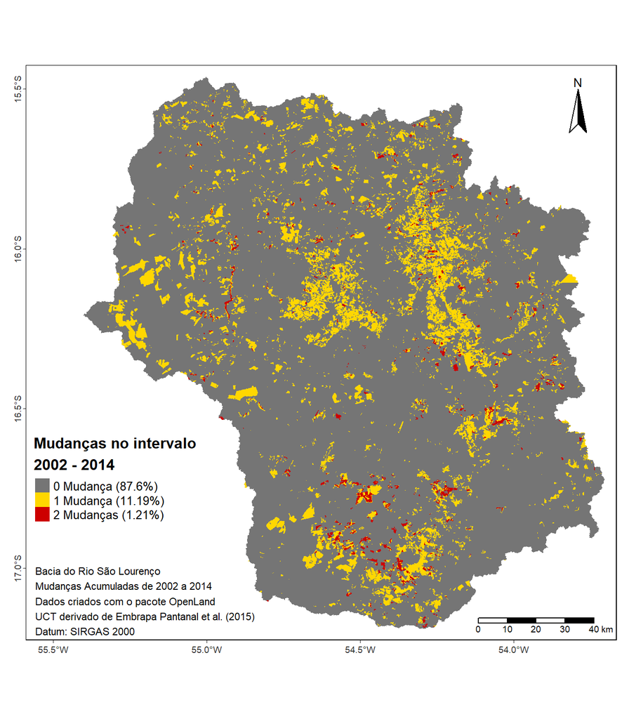

```r
# plotagem do mapa
acc_map
```

### Diagramas de transição

#### Chord Diagram

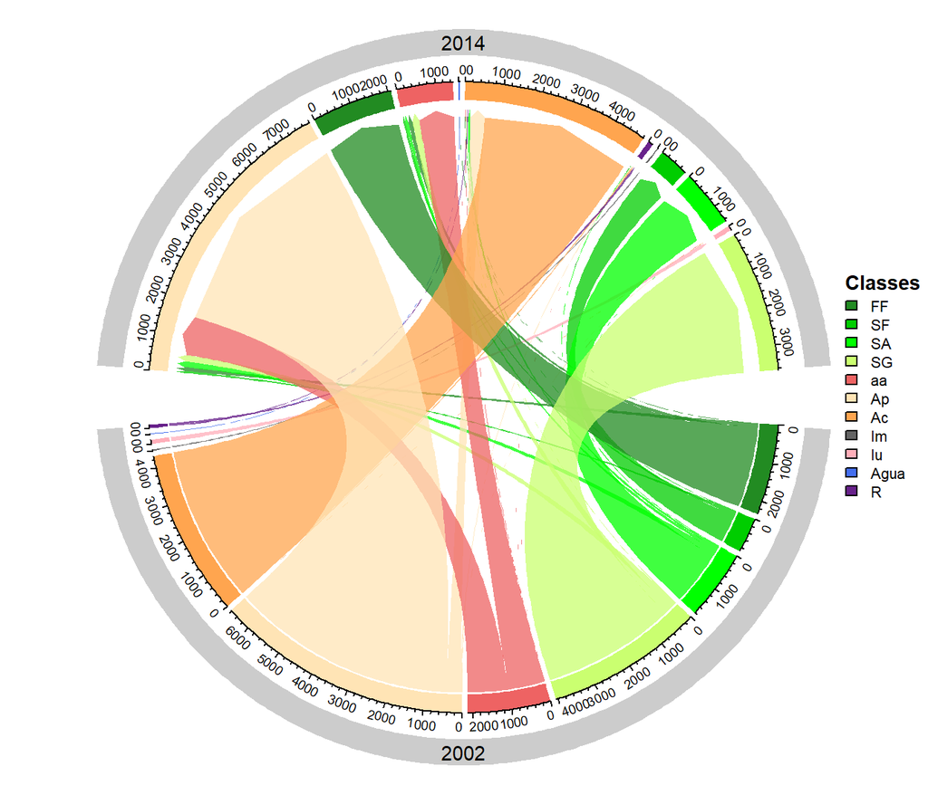

```r
chordDiagramLand(dataset = SL_2002_2014$lulc_Onestep,
                 legendtable = SL_2002_2014$tb_legend,
                 legposition = c(1, 0.30),
                 legtitle = "Classes", legendsize = .7)
```

#### Sankey plots

```r
# fluxo de mudança multipassos
sankeyLand(dataset = SL_2002_2014$lulc_Multistep,
           legendtable = SL_2002_2014$tb_legend)
```

[interactive chart not shown]

```r
# fluxo de mudança passo único
sankeyLand(dataset = SL_2002_2014$lulc_Onestep,
           legendtable = SL_2002_2014$tb_legend)
```

[interactive chart not shown]

### Evolução das áreas por classes de uso

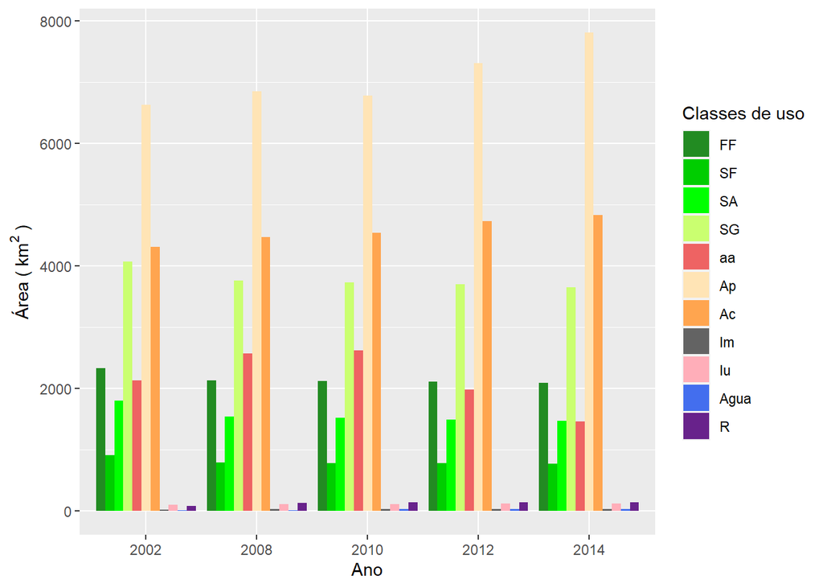

```r
# evolução das áreas ao longo da serie
barplotLand(dataset = SL_2002_2014$lulc_Multistep,
            legendtable = SL_2002_2014$tb_legend,
            area_km2 = T,
            xlab = "Ano",
            ylab = bquote("Área (" ~ km^2 ~ ")"),
            caption = "Classes de uso")
```

### Mudanças brutas e liquidas

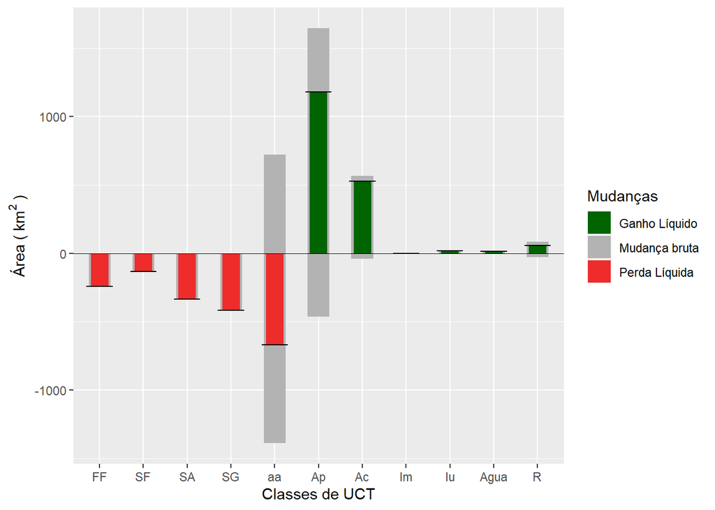

```r
netgrossplot(dataset = SL_2002_2014$lulc_Multistep,
             legendtable = SL_2002_2014$tb_legend,
             xlab = "Classes de UCT",
             ylab = bquote("Área (" ~ km^2 ~ ")"),
             legend_title = "Mudanças",
             changesLabel = c(GC = "Mudança bruta", NG = "Ganho Líquido", NL = "Perda Líquida"),
             color = c(GC = "gray70", NG = "#006400", NL = "#EE2C2C"))
```

## Analise de Intensidade

A função responsável pela análise é `intensityAnalysis()` recebe como entrada a lista inteira da saída da função `contingencyTable()`. Junto o usuário precisa informar uma categoria `n` e uma categoria `m`. Se o parâmetro `area_km2` é verdadeiro (`TRUE`), a análise é realizada em quilômetros quadrados, se for falso (`FALSE`) as saídas são dadas em número de pixels.

A função gera 6 objetos: *1)* `lulc_table`, *2)* `interval_lvl`, *3)* `category_lvlGain`, *4)* `category_lvlLoss`, *5)* `transition_lvlGain_n`, *6)* `transition_lvlLoss_m`.

```r
testSL <- intensityAnalysis(dataset = SL_2002_2014,
                            category_n = "Ap", category_m = "SG",
                            area_km2 = TRUE)

names(testSL)
```

```
## [1] "lulc_table"           "interval_lvl"         "category_lvlGain"
## [4] "category_lvlLoss"     "transition_lvlGain_n" "transition_lvlLoss_m"
```

### Plot dos objetos de intensidade

#### Nivel de intervalo

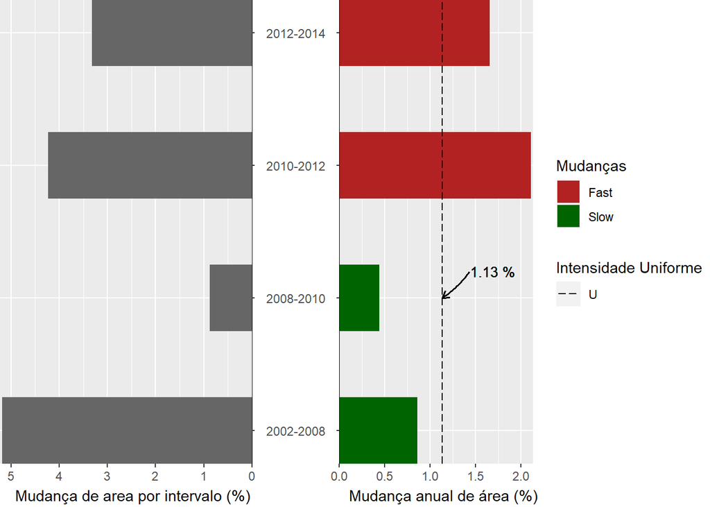

```r
plot(testSL$interval_lvl,
     labels = c(leftlabel = "Mudança de area por intervalo (%)",
                rightlabel = "Mudança anual de área (%)"),
     marginplot = c(-8, 0), labs = c("Mudanças", "Intensidade Uniforme"),
     leg_curv = c(x = .3, y = .2))
```

#### Nivel de categoria

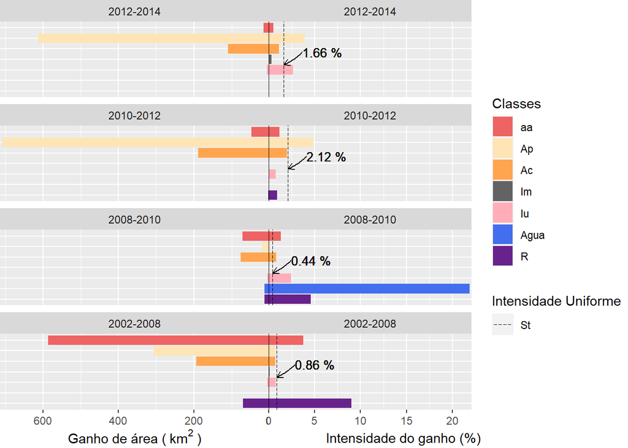

```r
# ganho
plot(testSL$category_lvlGain,
     labels = c(leftlabel = bquote("Ganho de área (" ~ km^2 ~ ")"),
                rightlabel = "Intensidade do ganho (%)"),
     marginplot = c(.3, .3), labs = c("Classes", "Intensidade Uniforme"),
     leg_curv = c(x = 2, y = 1.2))
```

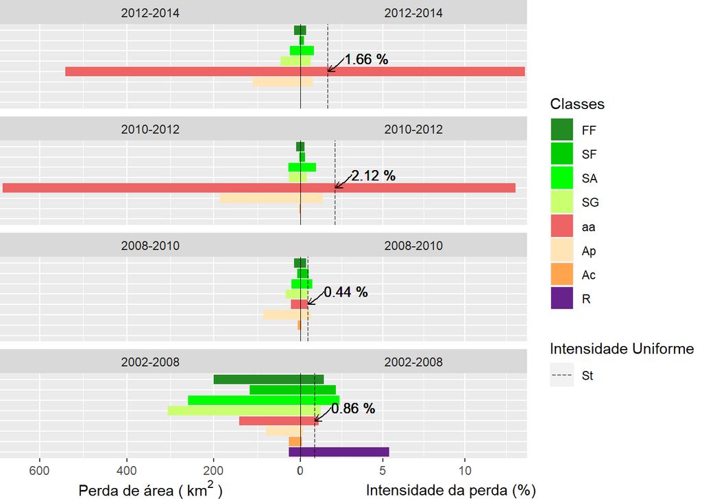

```r
# perda
plot(testSL$category_lvlLoss,
     labels = c(leftlabel = bquote("Perda de área (" ~ km ^ 2 ~ ")"),
                rightlabel = "Intensidade da perda (%)"),
     marginplot = c(.3, .3), labs = c("Classes", "Intensidade Uniforme"),
     leg_curv = c(x = 1, y = 1.3))
```

#### Nivel de transição

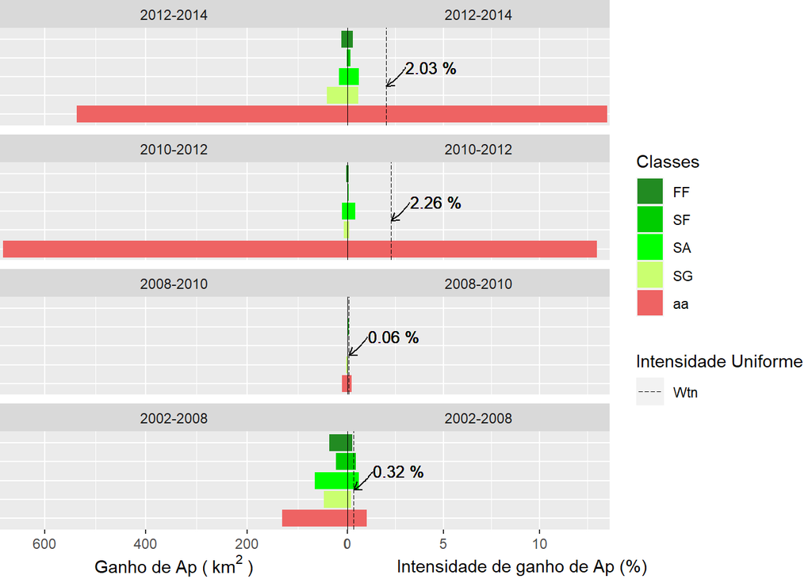

```r
# ganho
plot(testSL$transition_lvlGain_n,
     labels = c(leftlabel = bquote("Ganho de Ap (" ~ km ^ 2 ~ ")"),
                rightlabel = "Intensidade de ganho de Ap (%)"),
     marginplot = c(.3, .3), labs = c("Classes", "Intensidade Uniforme"),
     leg_curv = c(x = 1, y = 1))
```

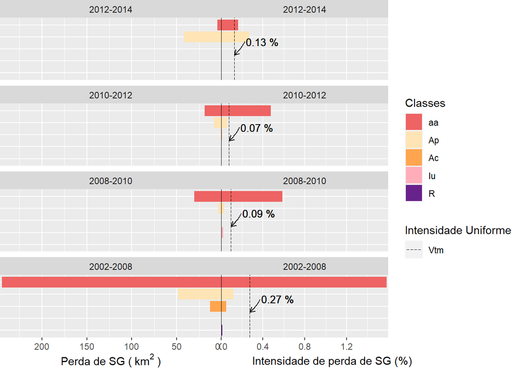

```r
# perda
plot(testSL$transition_lvlLoss_m,
     labels = c(leftlabel = bquote("Perda de SG (" ~ km^2 ~ ")"),
                rightlabel = "Intensidade de perda de SG (%)"),
     marginplot = c(.3, .3), labs = c("Classes", "Intensidade Uniforme"),
     leg_curv = c(x = .1, y = 1.1))
```

### Próximas versões

- Funções para perdas e ganhos de áreas
- Implementação de outras métricas

## Referencias

ALDWAIK, S. Z.; PONTIUS, R. G. Intensity analysis to unify measurements of size and stationarity of land changes by interval, category, and transition. Landscape and Urban Planning, v. 106, n. 1, p. 103–114, 2012. https://doi.org/10.1016/j.landurbplan.2012.02.010.

EMBRAPA PANTANAL; INSTITUTO SOS PANTANAL; WWF-BRASIL. Mapeamento da Bacia do Alto Paraguai. Disponível em: https://www.embrapa.br/pantanal/bacia-do-alto-paraguai. Acesso em: 22 ago. 2020.

EMBRAPA PANTANAL; INSTITUTO SOS PANTANAL; WWF-BRASIL. 2015. Monitoramento das alterações da cobertura vegetal e uso do Solo na Bacia do Alto Paraguai – Porção Brasileira – Período de Análise: 2012 a 2014. 4th ed. Brasilia. https://d3nehc6yl9qzo4.cloudfront.net/downloads/publicacao_bap_relatorio_2012_2014_web.pdf.

EXAVIER, R.; ZEILHOFER, P. OpenLand: Quantitative Analysis and Visualization of LUCC, 2020. https://cran.r-project.org/package=OpenLand.